# Happiness and Your ID

Simon Halliday

2015-September -15

In your class surveys, I asked you the last two digits of your 99 number and your reported happiness between 1 and 5. We can check whether you anchor your 99 numbers at all.

I first read in the data (the code will be suppressed in the html)

What is the hypothesis? Those people with higher ID numbers will report higher happiness, right?

So we group people into two categories:

- High if ID > 50
- Low if ID < 50

Now group by the two categories and create a graph:

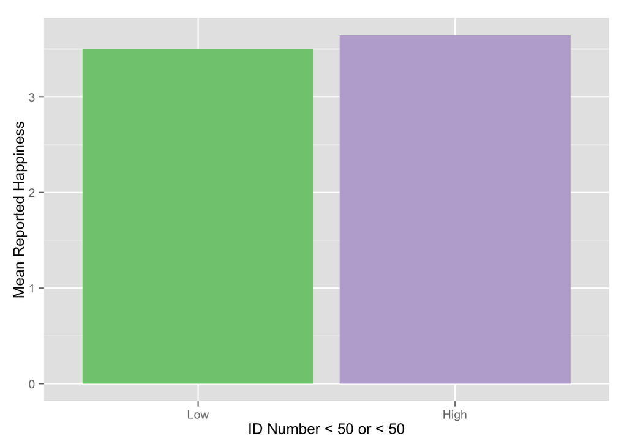

These don’t look too different. But, let’s do a t-test on these to check.

```
##
##  Welch Two Sample t-test
##
## data:  happyscale by bignumber
## t = -0.57204, df = 23.177, p-value = 0.5728
## alternative hypothesis: true difference in means is not equal to 0
## 95 percent confidence interval:
##  -0.6592500  0.3735357
## sample estimates:
## mean in group 0 mean in group 1
##        3.500000        3.642857
```

So, they are not statistically significantly different (the variable `bignumber` is a categorical variable).

Or, let’s put it into quartiles to check if we’re missing something with our aggregation:

- 1st Quartile: 0-24
- 2nd Quartile: 25-50
- 3rd Quartile: 51-74
- 4th Quartile: 75-99

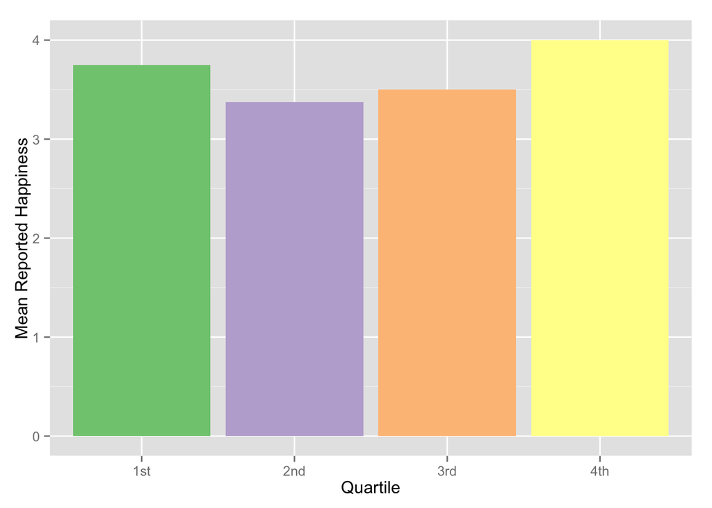

What about these, should we check for statistical significance? We could also check these for statistical significance. I suspect the sample sizes are too small, but for now we can simply check some baseline statistics for the four categories.

The following command `favstats` gives us the ‘favorite’ statistics we need to understand our sample (as Mari suspected, we have a small group in the 4th quartile). We want to see how the variable `happyscale` (the scale from 1 to 5) varies for each of the quartiles (labeled as the variable `q`):

```r
favstats(happyscale ~ q, data = HappyStudents)
```

```
##     q min   Q1 median Q3 max  mean        sd  n missing
## 1 1st   3 3.75    4.0  4   4 3.750 0.5000000  4       0
## 2 2nd   3 3.00    3.0  4   4 3.375 0.5175492  8       0
## 3 3rd   2 3.00    3.5  4   5 3.500 0.8498366 10       0
## 4 4th   4 4.00    4.0  4   4 4.000 0.0000000  4       0
```

And that’s that for now.